# NYPD shooting assignment

Nicholas

2022-06-11

### Downloading the data

RMD assignment. As per assignment instructions, 2 visualizations and 1 model is included.

First, we import the csv from the url.

```r
url_assignment = "https://data.cityofnewyork.us/api/views/833y-fsy8/rows.csv?accessType=DOWNLOAD"
```

### Cleaning the data

First, I would want to see what is inside the csv file. We will do the following.

1. Load up the csv file.
2. Take a look at the top 10 rows.

```r
library(tidyverse)
```

```r
nypdraw = read_csv(url_assignment)
summary(nypdraw)
```

```
##   INCIDENT_KEY        OCCUR_DATE         OCCUR_TIME           BORO
##  Min.   :  9953245   Length:25596       Length:25596      Length:25596
##  1st Qu.: 61593633   Class :character   Class1:hms        Class :character
##  Median : 86437258   Mode  :character   Class2:difftime   Mode  :character
##  Mean   :112382648                      Mode  :numeric
##  3rd Qu.:166660833
##  Max.   :238490103
##
##     PRECINCT      JURISDICTION_CODE LOCATION_DESC      STATISTICAL_MURDER_FLAG
##  Min.   :  1.00   Min.   :0.0000    Length:25596       Mode :logical
##  1st Qu.: 44.00   1st Qu.:0.0000    Class :character   FALSE:20668
##  Median : 69.00   Median :0.0000    Mode  :character   TRUE :4928
##  Mean   : 65.87   Mean   :0.3316
##  3rd Qu.: 81.00   3rd Qu.:0.0000
##  Max.   :123.00   Max.   :2.0000
##                   NA's   :2
##  PERP_AGE_GROUP       PERP_SEX          PERP_RACE         VIC_AGE_GROUP
##  Length:25596       Length:25596       Length:25596       Length:25596
##  Class :character   Class :character   Class :character   Class :character
##  Mode  :character   Mode  :character   Mode  :character   Mode  :character
##
##
##
##
##    VIC_SEX            VIC_RACE           X_COORD_CD        Y_COORD_CD
##  Length:25596       Length:25596       Min.   : 914928   Min.   :125757
##  Class :character   Class :character   1st Qu.:1000011   1st Qu.:182782
##  Mode  :character   Mode  :character   Median :1007715   Median :194038
##                                        Mean   :1009455   Mean   :207894
##                                        3rd Qu.:1016838   3rd Qu.:239429
##                                        Max.   :1066815   Max.   :271128
##
##     Latitude       Longitude        Lon_Lat
##  Min.   :40.51   Min.   :-74.25   Length:25596
##  1st Qu.:40.67   1st Qu.:-73.94   Class :character
##  Median :40.70   Median :-73.92   Mode  :character
##  Mean   :40.74   Mean   :-73.91
##  3rd Qu.:40.82   3rd Qu.:-73.88
##  Max.   :40.91   Max.   :-73.70
##
```

Next, as you can see, there is a total if 19 variables. I am more interested in the race of the perp and the victim, at this point in time, I would think that the datetime variable would prove to be useful in any analysis that I would be doing. Here are my next steps.

1. Take a smaller subset of the data > thereby dropping any columns I find irrelevant.
2. Look at the counts to ‘figure out’ the datset that I am looking at.

```r
nypd_perp = nypdraw %>%
select(c("BORO","OCCUR_DATE","OCCUR_TIME", "PERP_RACE"))

summary(nypd_perp)
```

```
##      BORO            OCCUR_DATE         OCCUR_TIME        PERP_RACE
##  Length:25596       Length:25596       Length:25596      Length:25596
##  Class :character   Class :character   Class1:hms        Class :character
##  Mode  :character   Mode  :character   Class2:difftime   Mode  :character
##                                        Mode  :numeric
```

```r
nypd_perp %>% head
```

```
## # A tibble: 6 × 4
##   BORO      OCCUR_DATE OCCUR_TIME PERP_RACE
##   <chr>     <chr>      <time>     <chr>
## 1 BRONX     08/27/2006 05:35      <NA>
## 2 QUEENS    03/11/2011 12:03      <NA>
## 3 BRONX     04/14/2021 21:08      <NA>
## 4 BRONX     12/10/2021 19:30      <NA>
## 5 MANHATTAN 02/22/2021 00:18      <NA>
## 6 BROOKLYN  03/07/2021 06:15      BLACK HISPANIC
```

```r
nypd_grouped_perprace = nypd_perp %>%
group_by(PERP_RACE) %>%
summarize(n())
nypd_grouped_perprace
```

```
## # A tibble: 8 × 2
##   PERP_RACE                      `n()`
##   <chr>                          <int>
## 1 AMERICAN INDIAN/ALASKAN NATIVE     2
## 2 ASIAN / PACIFIC ISLANDER         141
## 3 BLACK                          10668
## 4 BLACK HISPANIC                  1203
## 5 UNKNOWN                         1836
## 6 WHITE                            272
## 7 WHITE HISPANIC                  2164
## 8 <NA>                            9310
```

### Visualization of Data

As we can see from the variable: nypd_grouped_perprace, the top perp race implicated in NYPD shootings are blacks. For my visualization, I would like to see two things:

1. A simple bar graph for perp races.
2. Cases over time for blacks and overall

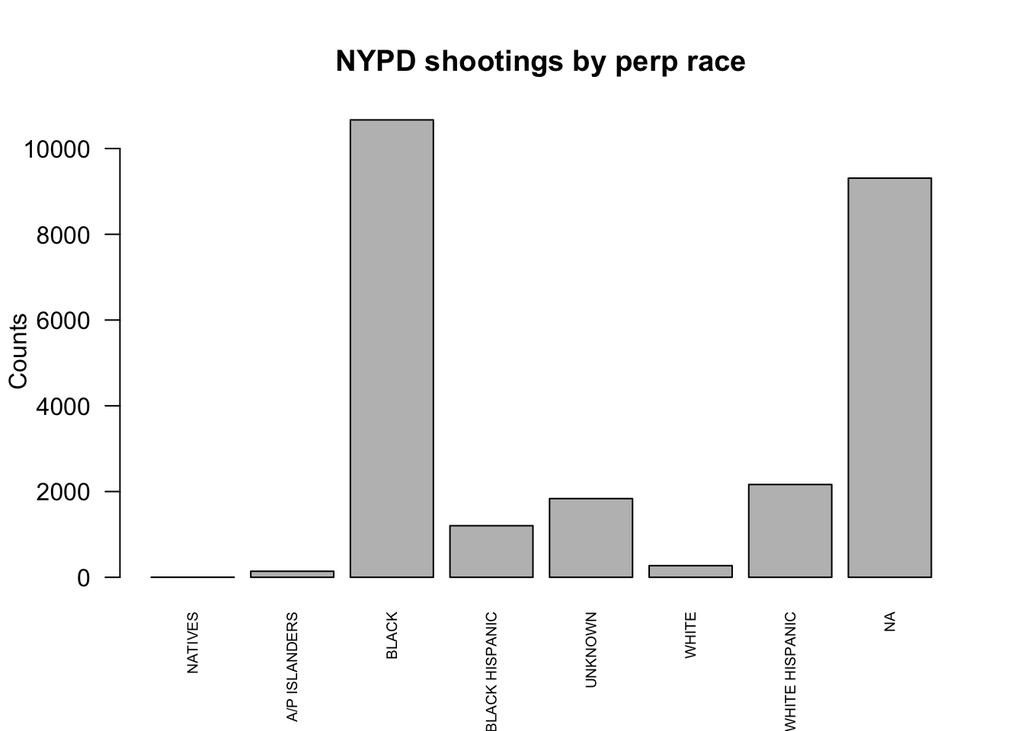

```r
race4perps = na.omit(nypd_grouped_perprace$PERP_RACE)
race4perps = append(race4perps, "NA")
race4perps = replace(race4perps, race4perps == "AMERICAN INDIAN/ALASKAN NATIVE", "NATIVES")
race4perps = replace(race4perps, race4perps == "ASIAN / PACIFIC ISLANDER", "A/P ISLANDERS")
barplot(nypd_grouped_perprace$`n()`, main = 'NYPD shootings by perp race', ylab = 'Counts', names.arg =  race4perps, las=2, cex.names = 0.6)
```

As one can see from the barplots above, we will now attempt a second visualization to track the total number of PERP_RACE == BLACK, implicated in NYPD shootings, against the total number shootings over time.

```r
library(lubridate)
nypd_perp_dated = nypd_perp %>%
select(c("OCCUR_DATE", "PERP_RACE"))
nypd_perp_dated = nypd_perp_dated %>%
mutate(OCCUR_DATE = mdy(OCCUR_DATE))
nypd_perp_dated
```

```
## # A tibble: 25,596 × 2
##    OCCUR_DATE PERP_RACE
##    <date>     <chr>
##  1 2006-08-27 <NA>
##  2 2011-03-11 <NA>
##  3 2021-04-14 <NA>
##  4 2021-12-10 <NA>
##  5 2021-02-22 <NA>
##  6 2021-03-07 BLACK HISPANIC
##  7 2021-07-21 BLACK
##  8 2021-09-11 <NA>
##  9 2021-05-09 BLACK
## 10 2021-04-23 <NA>
## # … with 25,586 more rows
```

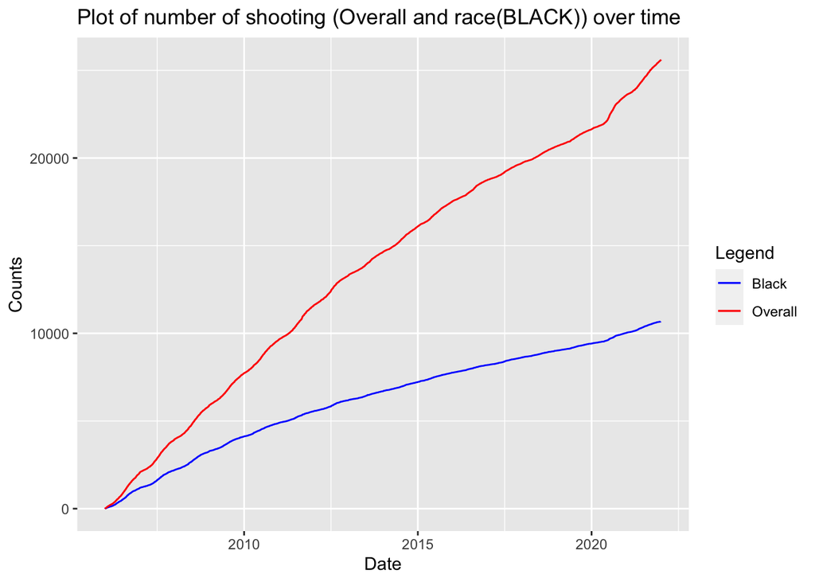

```r
race_subset = nypd_perp_dated %>%
filter(PERP_RACE == "BLACK")

race_subset = race_subset[order(race_subset$OCCUR_DATE), ]
race_subset = race_subset %>%
mutate(counted_race = sequence(n()))

all_subset = nypd_perp_dated
all_subset = all_subset[order(all_subset$OCCUR_DATE),]
all_subset = all_subset %>%
mutate(counted_race2 = sequence(n()))

colors = c("Black" = "blue", "Overall" = "red")

race_subset %>%
ggplot(aes(x=OCCUR_DATE, y=counted_race))+
geom_line(aes(color= "Black"))+
geom_line(data = all_subset, aes(x=OCCUR_DATE, y=counted_race2, color = "Overall")) +
labs(title = "Plot of number of shooting (Overall and race(BLACK)) over time", y= "Counts", x = "Date", color = "Legend") +
scale_color_manual(values=colors)
```

### Data Modelling

The last part of the assignment requires a modelling. We will do a simple modelling of the number of race = BLACK against the overall number of shootings. Let us see how it turns up against a linear model.

```r
combined = nypd_perp_dated[order(nypd_perp_dated$OCCUR_DATE),]

combined = combined %>%
group_by(PERP_RACE) %>%
mutate(counted_race = sequence(n()))
combined$index = 1:nrow(combined)

combined = combined %>%
filter(PERP_RACE == 'BLACK')

mod = lm( counted_race ~ index , data = combined)
summary(mod)
```

```
##
## Call:
## lm(formula = counted_race ~ index, data = combined)
##
## Residuals:
##     Min      1Q  Median      3Q     Max
## -620.61 -141.93  -11.36  185.15  385.37
##
## Coefficients:
##              Estimate Std. Error t value Pr(>|t|)
## (Intercept) 6.206e+02  4.303e+00   144.2   <2e-16 ***
## index       4.090e-01  3.129e-04  1307.3   <2e-16 ***
## ---
## Signif. codes:  0 '***' 0.001 '**' 0.01 '*' 0.05 '.' 0.1 ' ' 1
##
## Residual standard error: 242.5 on 10666 degrees of freedom
## Multiple R-squared:  0.9938, Adjusted R-squared:  0.9938
## F-statistic: 1.709e+06 on 1 and 10666 DF,  p-value: < 2.2e-16
```

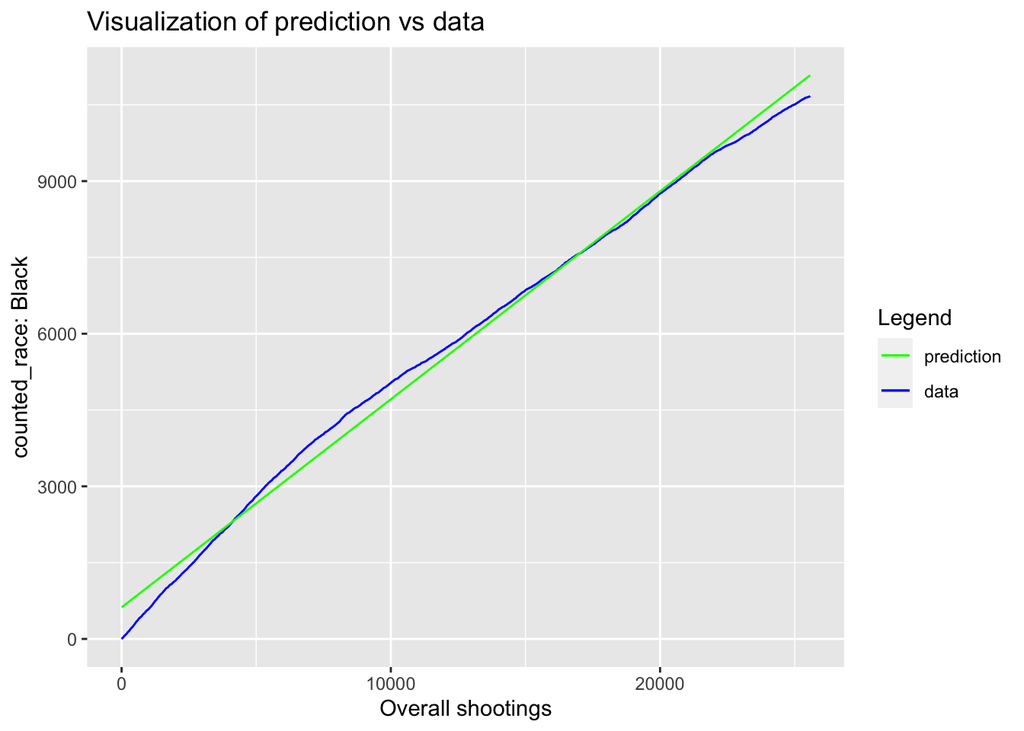

```r
combined = combined %>% mutate(pred = predict(mod))

color_2 = c("prediction" = 'green', "data" = 'blue')

combined %>% ggplot()+
geom_line(aes(x = index , y = counted_race, color = 'data'))+
geom_line(aes(x= index , y= pred, color = 'prediction')) +
labs(title = 'Visualization of prediction vs data', y = 'counted_race: Black', x='Overall shootings', color = 'Legend')+
scale_color_manual(values = color_2)
```

One glaring bias of my brief analysis is that I have failed to look at the incidents per borough and other relevant data. Regardless of race, we do know that socioeconomical issues pervades the notion of crime. A more thorough analysis that looks at data such as crime rates/ borough and linking it education, financial status, marital status of parents etc. will allow us to better analyze the issue of ‘perps’ committing crime and not gloss over it as simply - a racial issue.